# DAB 502 : LAB 3

## Pallavi Ravikumar Menon

### I. Load packages

```r
library(tidyverse)
library(here)
library(ggplot2)
library(oilabs)
```

### 2. Read Data

```r
nc <- read_csv(here('data', 'ncbirths.csv'))
```

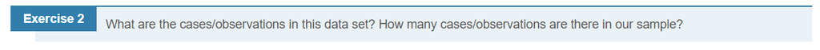

```r
dim(nc)
```

```
## [1] 1000   12
```

```r
head(nc)
```

```
## # A tibble: 6 x 12
##    fage  mage mature weeks premie visits marital gained weight lowbirthweight
##   <dbl> <dbl> <chr>  <dbl> <chr>   <dbl>   <dbl>  <dbl>  <dbl> <chr>
## 1    NA    13 young~    39 full ~     10       2     38   7.63 not low
## 2    NA    14 young~    42 full ~     15       2     20   7.88 not low
## 3    19    15 young~    37 full ~     11       2     38   6.63 not low
## 4    21    15 young~    41 full ~      6       2     34   8    not low
## 5    NA    15 young~    39 full ~      9       2     27   6.38 not low
## 6    NA    15 young~    38 full ~     19       2     22   5.38 low
## # ... with 2 more variables: gender <chr>, habit <chr>
```

```r
summary(nc)
```

```
##       fage            mage       mature              weeks
##  Min.   :14.00   Min.   :13   Length:1000        Min.   :20.00
##  1st Qu.:25.00   1st Qu.:22   Class :character   1st Qu.:37.00
##  Median :30.00   Median :27   Mode  :character   Median :39.00
##  Mean   :30.26   Mean   :27                      Mean   :38.33
##  3rd Qu.:35.00   3rd Qu.:32                      3rd Qu.:40.00
##  Max.   :55.00   Max.   :50                      Max.   :45.00
##  NA's   :171                                     NA's   :2
##     premie              visits        marital          gained
##  Length:1000        Min.   : 0.0   Min.   :1.000   Min.   : 0.00
##  Class :character   1st Qu.:10.0   1st Qu.:1.000   1st Qu.:20.00
##  Mode  :character   Median :12.0   Median :1.000   Median :30.00
##                     Mean   :12.1   Mean   :1.386   Mean   :30.33
##                     3rd Qu.:15.0   3rd Qu.:2.000   3rd Qu.:38.00
##                     Max.   :30.0   Max.   :2.000   Max.   :85.00
##                     NA's   :9      NA's   :1       NA's   :27
##      weight       lowbirthweight        gender             habit
##  Min.   : 1.000   Length:1000        Length:1000        Length:1000
##  1st Qu.: 6.380   Class :character   Class :character   Class :character
##  Median : 7.310   Mode  :character   Mode  :character   Mode  :character
##  Mean   : 7.101
##  3rd Qu.: 8.060
##  Max.   :11.750
##
```

## Exploratory data analysis

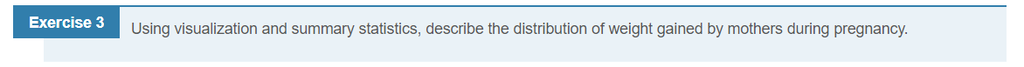

```r
summary(nc$gained)
```

```
##    Min. 1st Qu.  Median    Mean 3rd Qu.    Max.    NA's
##    0.00   20.00   30.00   30.33   38.00   85.00      27
```

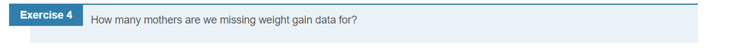

**After reading the above ssummary statistics,there are 27 missing weight gain data.**

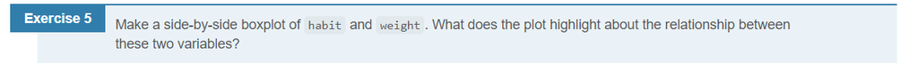

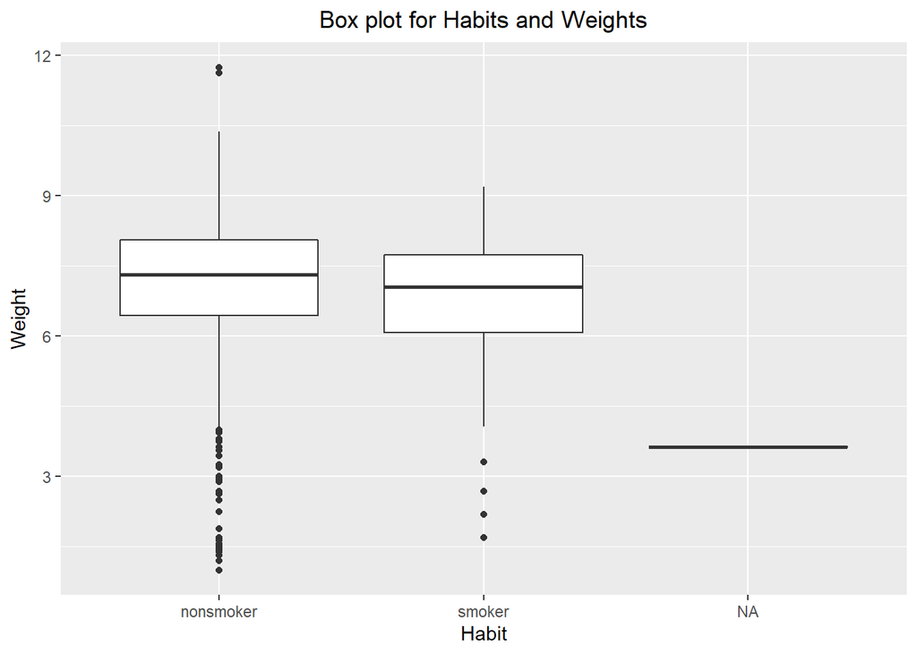

```r
plot1 <- ggplot(nc, aes(habit,weight)) + geom_boxplot() +
         ggtitle("Box plot for Habits and Weights") + theme_gray() + labs(x = "Habit",  y = "Weight")+ theme(plot.title = element_text (hjust = 0.5))
plot1
```

**As we can see from the plot the nonsmoker distribution is extremely skewed and has more number of outlier, whereas there are few outlier for mothers who have smoking habits. We can also see there are null values in the dataset.**

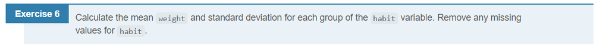

```r
by(nc$weight, nc$habit, summary)
```

```
## nc$habit: nonsmoker
##    Min. 1st Qu.  Median    Mean 3rd Qu.    Max.
##   1.000   6.440   7.310   7.144   8.060  11.750
## ------------------------------------------------------------
## nc$habit: smoker
##    Min. 1st Qu.  Median    Mean 3rd Qu.    Max.
##   1.690   6.077   7.060   6.829   7.735   9.190
```

```r
#Removing null values from "habit" column
nc <- nc[!nc$habit == "null", ]
```

```r
#calculating the mean weight
nc %>%
  group_by(habit) %>%
  summarise(mean_weight = mean(weight),
            Standard_deviation = sd(weight))
```

```
## # A tibble: 3 x 3
##   habit     mean_weight Standard_deviation
## * <chr>           <dbl>              <dbl>
## 1 nonsmoker        7.14               1.52
## 2 smoker           6.83               1.39
## 3 <NA>            NA                 NA
```

## Inference

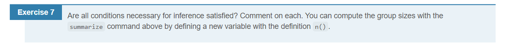

**As per the observation till now we can see that the samples within each group are independent . Also the sample sizes are large enough and the skewness wooul not impact the results.**

```r
# Computing the group size with n()
nc %>%
   group_by(habit) %>%
   summarise(group_size = n())
```

```
## # A tibble: 3 x 2
##   habit     group_size
## * <chr>          <int>
## 1 nonsmoker        873
## 2 smoker           126
## 3 <NA>               1
```

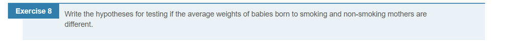

**H0: There is no difference between the mean weights of children born from smoking mothers and non-smoking mothers.**

**HA: There is a difference between the mean weights of children born from smoking mothers and non-smoking mothers.**

```r
inference(y = weight, x = habit, data = nc, statistic = "mean", type = "ht", null = 0,
          alternative = "twosided", method = "theoretical")
```

```
## Response variable: numerical
## Explanatory variable: categorical (2 levels)
## n_nonsmoker = 873, y_bar_nonsmoker = 7.1443, s_nonsmoker = 1.5187
## n_smoker = 126, y_bar_smoker = 6.8287, s_smoker = 1.3862
## H0: mu_nonsmoker =  mu_smoker
## HA: mu_nonsmoker != mu_smoker
## t = 2.359, df = 125
## p_value = 0.0199
```

[figure not shown]

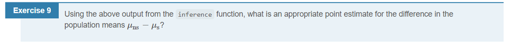

```r
μns <- 7.1443
μs <- 6.8287

point_estimate <- μns - μs
point_estimate
```

```
## [1] 0.3156
```

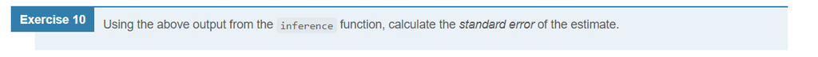

**The standard error is 0.13379 based on the above inference**

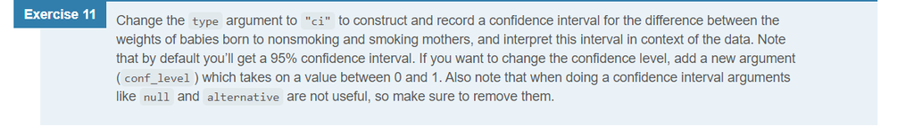

```r
inference(y = weight, x = habit, data = nc, statistic = "mean", type = "ci",
          method = "theoretical", order = c("smoker","nonsmoker"))
```

```
## Response variable: numerical, Explanatory variable: categorical (2 levels)
## n_smoker = 126, y_bar_smoker = 6.8287, s_smoker = 1.3862
## n_nonsmoker = 873, y_bar_nonsmoker = 7.1443, s_nonsmoker = 1.5187
## 95% CI (smoker - nonsmoker): (-0.5803 , -0.0508)
```

[figure not shown]